# Explanatory Analysis on US Election Results for 1992 in Preparation for Prediction Tasks

For the 5th and final project I decided to use a dataset that I compiled for a class project for my master's in statistics. However, due to the time-limits associated with the length of the presentation I did not get to present much of the exploratory analysis I conducted. In this project I will use EDA to explore the structure of the data.

These data are from two sources:

- [U.S. County Vote for Clinton 1992 & Demographics](http://users.stat.ufl.edu/~winner/datasets.html)
- [Wikipedia](https://en.wikipedia.org/wiki/1992_United_States_presidential_election)

The purpose of this explanatory analysis is as follows:

- Were there more counties that voted for Clinton or Bush?
  - This gives us a good idea of the class balance for the response variable.
- Do states that Clinton/Bush won have vote percentages at or above 50%?
- What is the vote percentage breakdown for each of the regions of the U.S?
- What is the vote percentage breakdown for the regions that voted democrat or republican?
- Are there large differences in the demographic measurements/variables for counties that voted democrat or republican?
  - This will give us insight as to whether a MANOVA based on the Wilk's test would reject the null hypothesis or not.

## Were there more counties that voted for Clinton or Bush?

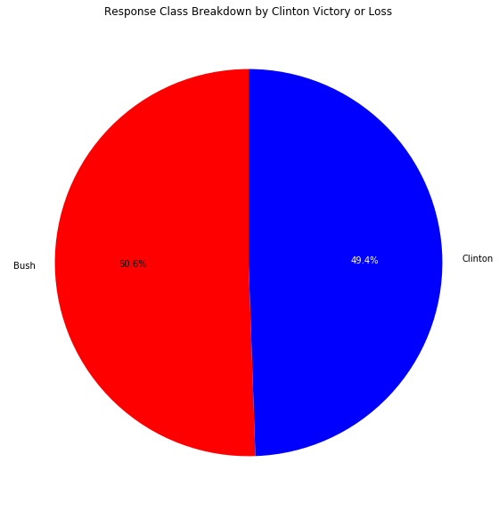

## Do states that Clinton/Bush won have vote percentages at or above 50%?

As can be seen from the bar-plot, the vast majority of states that swung to the left or right for a particular candidate did not have vote percentages at or above 50% for their victorious candidates. This indicates a significant non-partisan candidate presence among voters for this year.

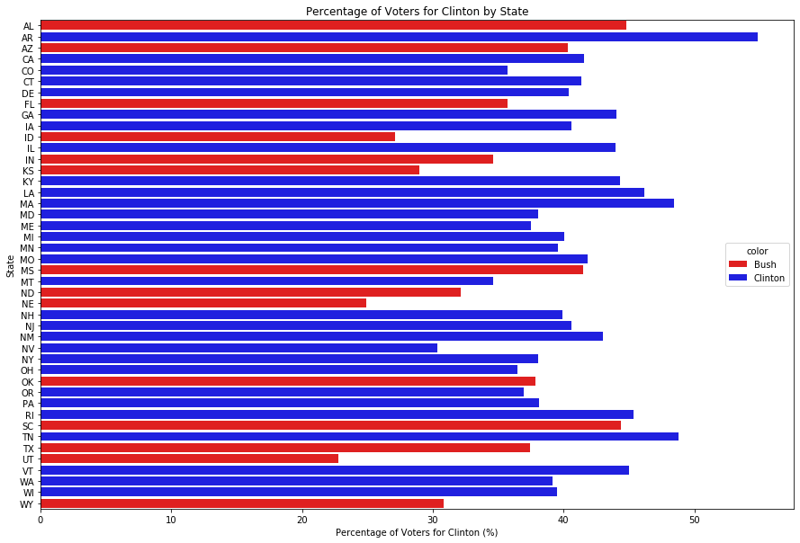

## Question 3: What is the vote percentage breakdown for each of the regions of the U.S?

As can be seen from the bar-plot, the southeast had the largest percentage of voters that voted for the democratic candidate, Bill Clinton, with the midwest having the smallest. This is interesting because the southeast has traditionally been a republican stronghold.

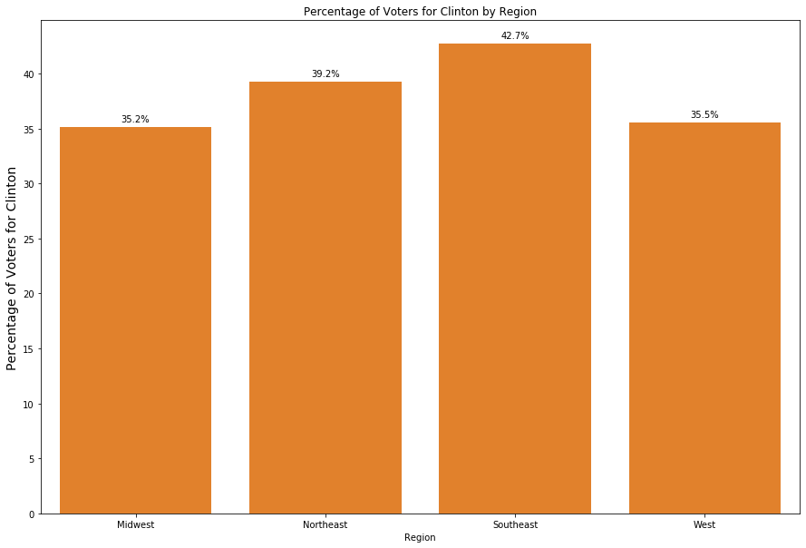

## What is the vote percentage breakdown for the regions that voted democrat or republican?

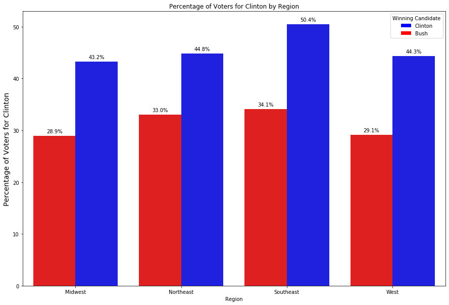

## Are there large differences in the demographic measurements/variables for counties that voted democrat or republican?

In the figure below I give the boxplots for the demographic variables that had the greatest difference in their medians/means. In addition, I plot the mean of each demographic variables using an orange dot superimposed on the boxplot.

As can be seen, there *is* a discernible difference between the measurements of the demographic variables between counties that Clinton lost and won. These differences do seem to be pretty small for 3/4 of the variables. It is evident that financially less able counties seem to have voted for Clinton and that counties that have a larger female population tended to vote for Clinton as well.

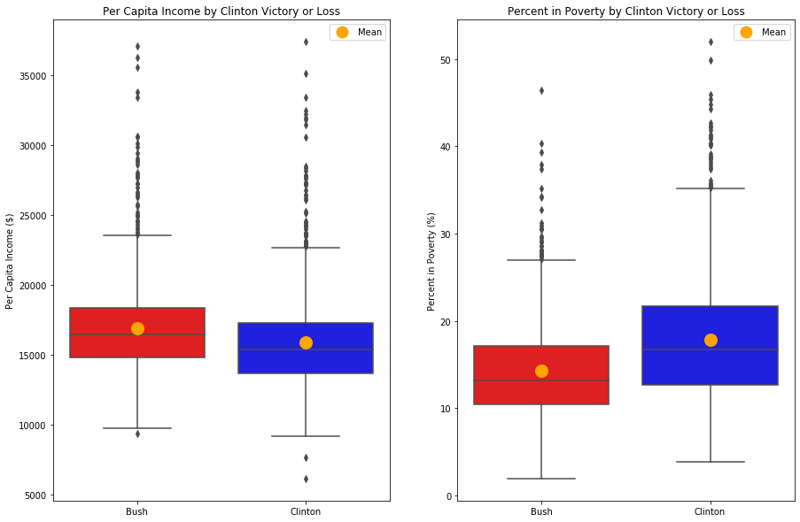

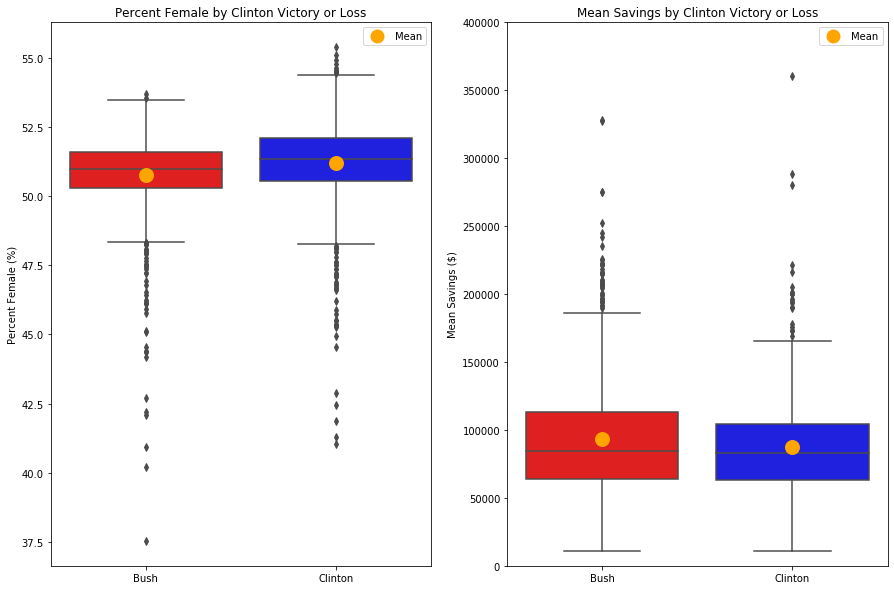